# jsQuestPlusHistogram

Daiichiro Kuroki

2022/1/19

# jsQuestPlus simulation

We show below how accurately jsQuestPlus could estimate the psychometric parameters in the simulations described in our paper.

We obtained simulation data of 37 browser–computer combinations. In other words, we obtained 37 estimates for each psychometric parameter. Each histogram shows the frequency of the 37 estimates.

## Simulation 1

This simulation corresponds to the example 1 of Watson (2017): Estimation of contrast threshold {1, 1, 2}

- The number of stimulus parameters is 1
- The number of psychometric parameters is 1
- The number of responses is 2
- The number of samples is 3362

### Threshold (True value is -20)

*Possible values: -40, -39, -38, …, -1, 0*

```r
dat_jsqp <- read.table('jsQuestPlus_20220111.csv', sep=",", header=T)
sub_dat <- subset(dat_jsqp, trial_index == 1) # Retrieve 37 estimates from raw data.
summary(sub_dat$ex1_threshold)
```

```
##    Min. 1st Qu.  Median    Mean 3rd Qu.    Max.
##  -31.00  -21.00  -20.00  -19.97  -19.00  -16.00
```

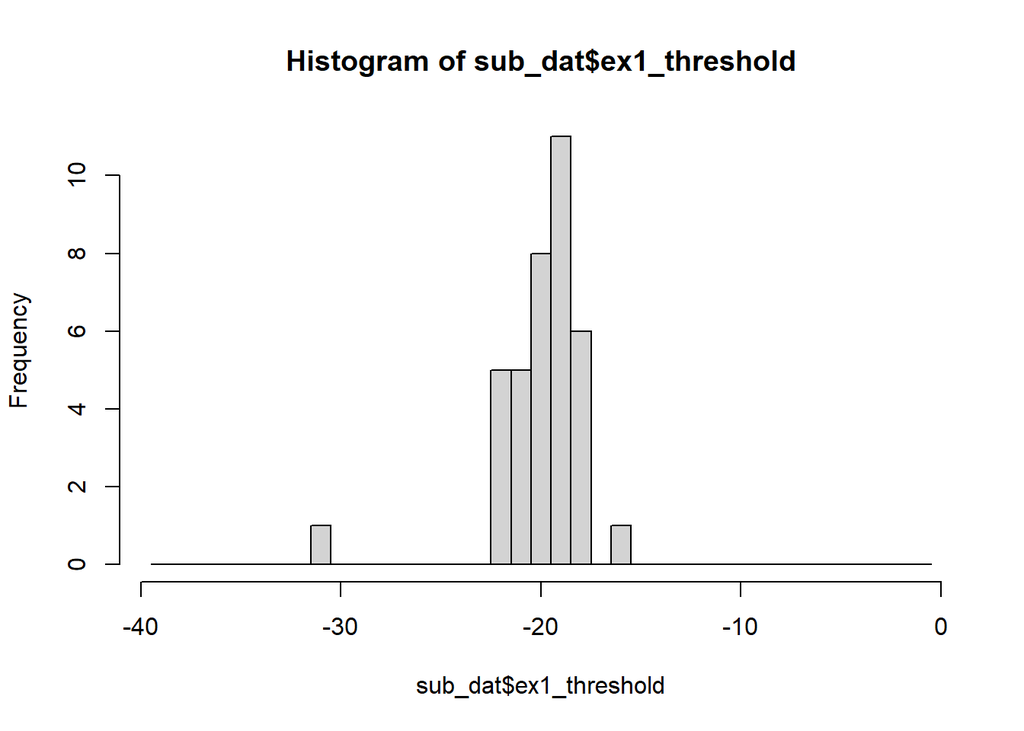

```r
hist(sub_dat$ex1_threshold, seq(-39.5,0))
```

## Simulation 2

This simulation corresponds to the example 2 of Watson (2017): Estimation of contrast threshold, slope, and lapse {1, 3, 2}

- The number of stimulus parameters is 1
- The number of psychometric parameters is 3
- The number of responses is 2
- The number of samples is 67240

### Threshold (True value is -20)

*Possible values: -40, -39, -38, …, -1, 0*

```r
summary(sub_dat$ex2_threshold)
```

```
##    Min. 1st Qu.  Median    Mean 3rd Qu.    Max.
##  -22.00  -20.00  -20.00  -19.78  -19.00  -18.00
```

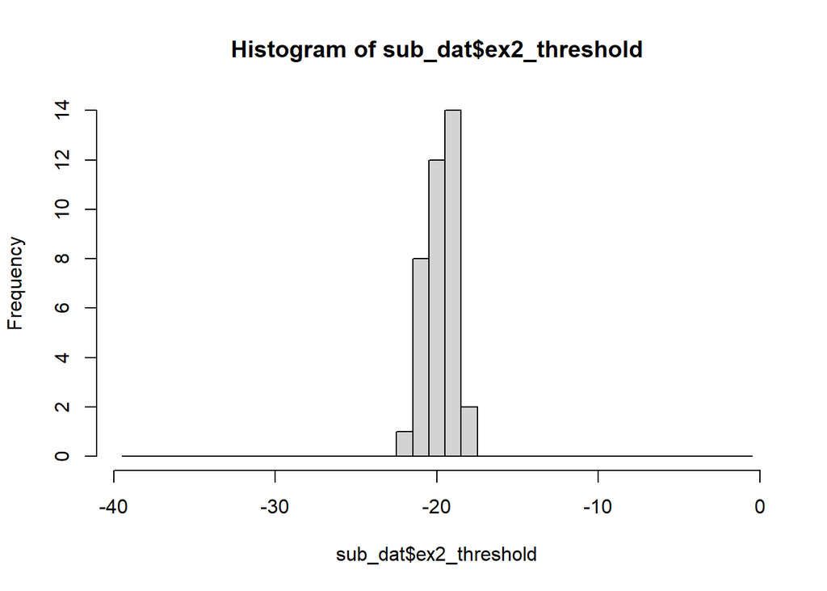

```r
hist(sub_dat$ex2_threshold, seq(-39.5,0))
```

### Slope (True value is 3)

*Possible values: 2, 3, 4, 5*

```r
summary(sub_dat$ex2_slope)
```

```
##    Min. 1st Qu.  Median    Mean 3rd Qu.    Max.
##   2.000   2.000   5.000   3.919   5.000   5.000
```

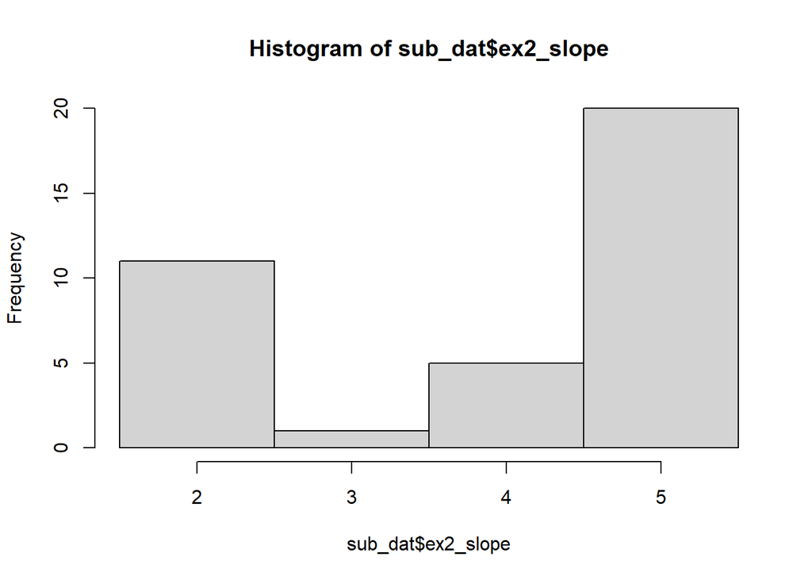

```r
hist(sub_dat$ex2_slope, seq(1.5, 5.5))
```

### Lapse (True value is 0.02)

*Possible values: 0, 0.01, 0.02, 0.03, 0.04*

```r
summary(sub_dat$ex2_lapse)
```

```
##     Min.  1st Qu.   Median     Mean  3rd Qu.     Max.
## 0.000000 0.000000 0.000000 0.007297 0.010000 0.040000
```

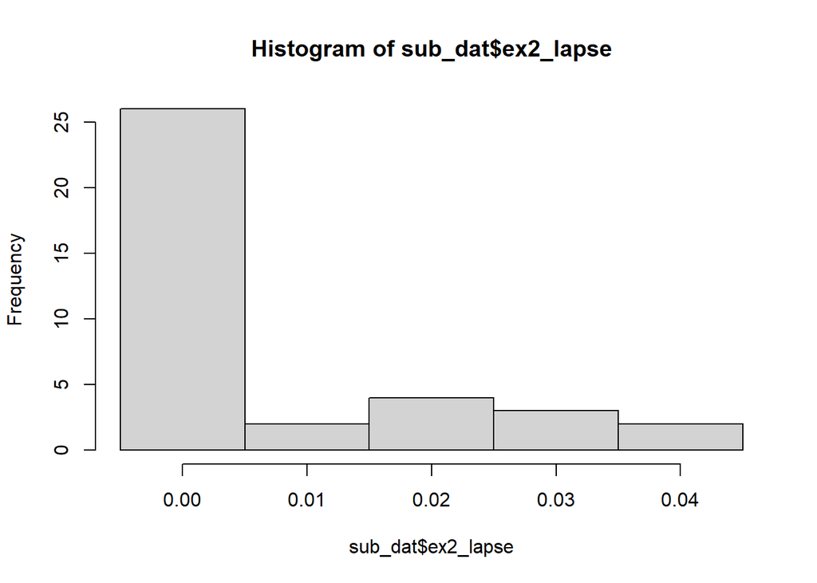

```r
hist(sub_dat$ex2_lapse, seq(-0.005,0.045,0.01))
```

## Simulation 3

This simulation corresponds to the example 4 of Watson (2017): Contrast sensitivity function {2, 3, 2}

- The number of stimulus parameters is 2
- The number of psychometric parameters is 3
- The number of responses is 2
- The number of samples is 660660

### Threshold (True value is -35)

*Possible values: -50, -49, -48, …, -31, -30*

```r
summary(sub_dat$ex4_threshold)
```

```
##    Min. 1st Qu.  Median    Mean 3rd Qu.    Max.
##   -50.0   -36.0   -34.0   -34.7   -32.0   -30.0
```

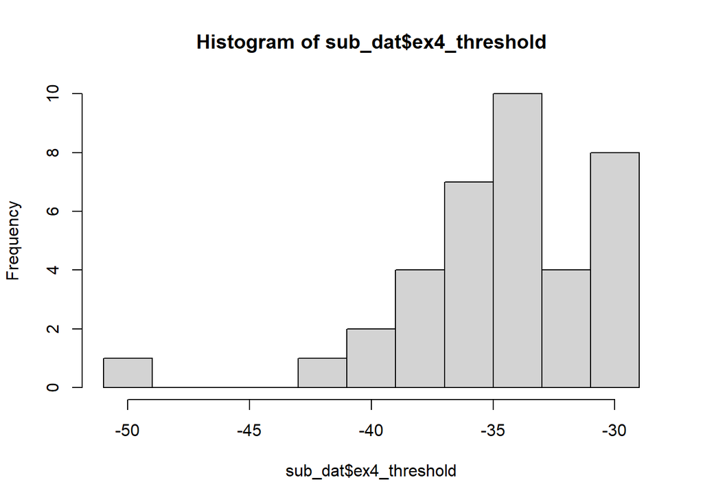

```r
hist(sub_dat$ex4_threshold, seq(-51,-29,2))
```

### C0 (True value is -50)

*Possible values: -60, -58, -56, …, -42, -40*

```r
summary(sub_dat$ex4_c0)
```

```
##    Min. 1st Qu.  Median    Mean 3rd Qu.    Max.
##  -60.00  -52.00  -50.00  -49.84  -46.00  -42.00
```

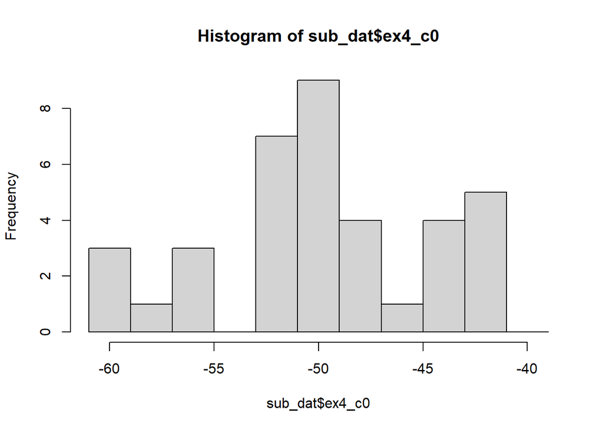

```r
hist(sub_dat$ex4_c0, seq(-61,-39,2))
```

### Cf (True value is 1.2)

*Possible values: 0.8, 1.0, 1.2, 1.4, 1.6*

```r
summary(sub_dat$ex4_cf)
```

```
##    Min. 1st Qu.  Median    Mean 3rd Qu.    Max.
##   1.000   1.200   1.200   1.189   1.200   1.600
```

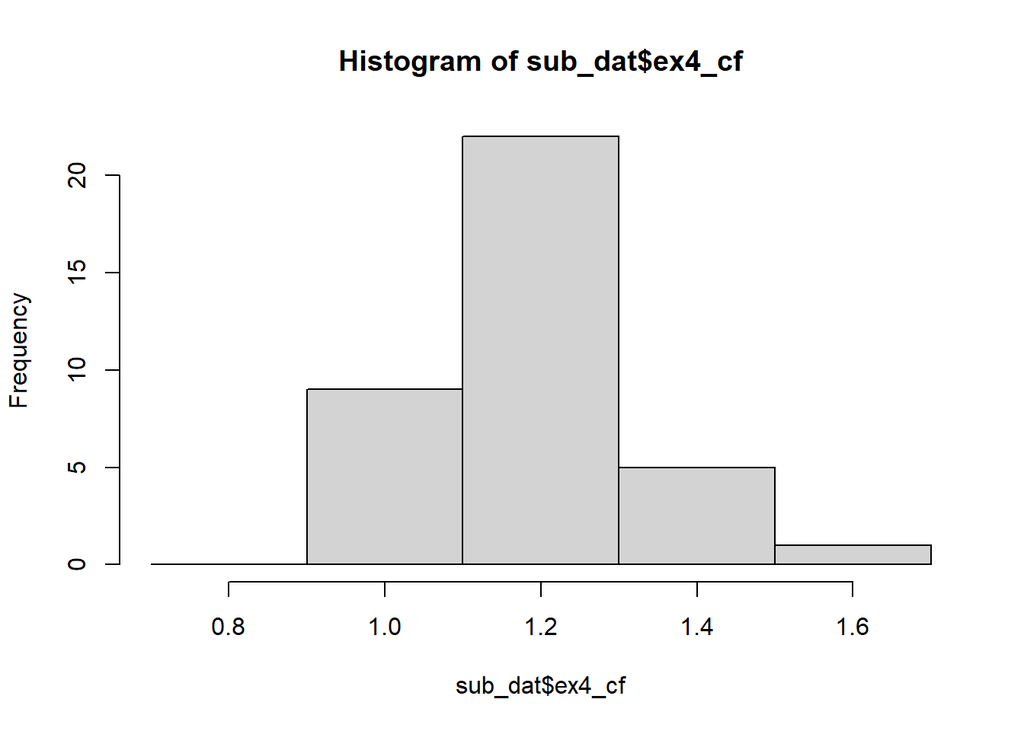

```r
hist(sub_dat$ex4_cf, seq(0.7,1.7,0.2))
```

## Simulation 4

This simulation corresponds to the example 5 of Watson (2017): Spatiotemporal contrast sensitivity {3, 4, 2}

- The number of stimulus parameters is 3
- The number of psychometric parameters is 4
- The number of responses is 2
- The number of samples is 911250

### Threshold (True value is -40)

*Possible values: -50, -45, -40, -35, -30*

```r
summary(sub_dat$ex5_threshold)
```

```
##    Min. 1st Qu.  Median    Mean 3rd Qu.    Max.
##  -50.00  -40.00  -40.00  -40.95  -40.00  -35.00
```

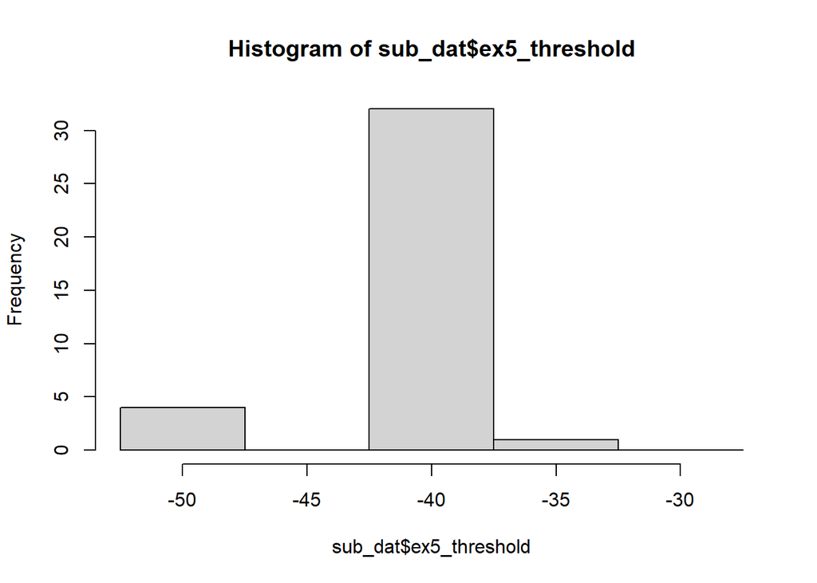

```r
hist(sub_dat$ex5_threshold, seq(-52.5, -27.5, 5))
```

### C0 (True value is -50)

*Possible values: -60, -55, -50, -45, -40*

```r
summary(sub_dat$ex5_c0)
```

```
##    Min. 1st Qu.  Median    Mean 3rd Qu.    Max.
##  -60.00  -50.00  -50.00  -50.68  -50.00  -40.00
```

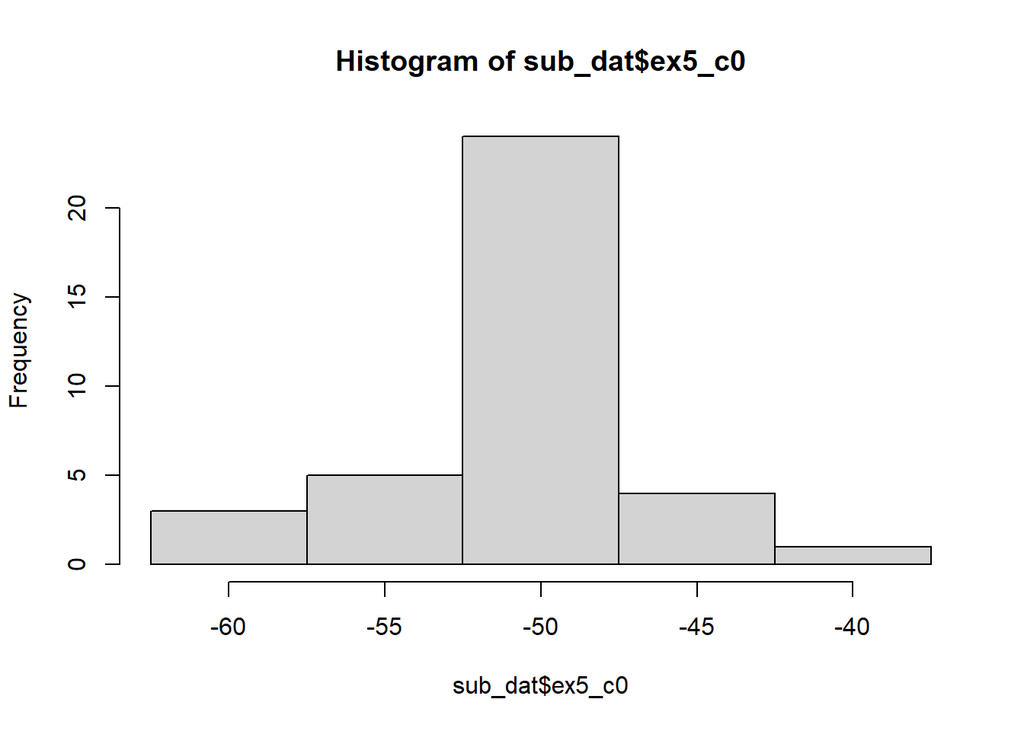

```r
hist(sub_dat$ex5_c0, seq(-62.5, -37.5, 5))
```

### Cf (True value is 1.2)

*Possible values: 0.8, 1.0, 1.2, 1.4, 1.6*

```r
summary(sub_dat$ex5_cf)
```

```
##    Min. 1st Qu.  Median    Mean 3rd Qu.    Max.
##   0.800   1.200   1.200   1.216   1.200   1.600
```

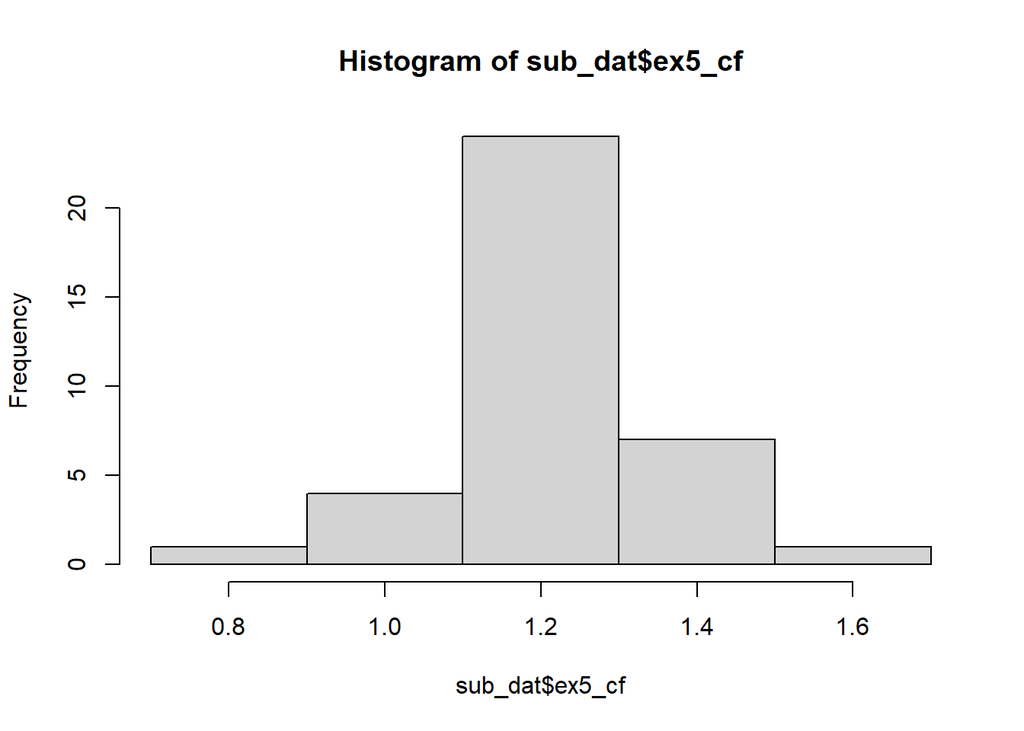

```r
hist(sub_dat$ex5_cf, seq(0.7,1.7,0.2))
```

### Cw (True value is 1.0)

*Possible values: 0.8, 1.0, 1.2, 1.4, 1.6*

```r
summary(sub_dat$ex5_cw)
```

```
##    Min. 1st Qu.  Median    Mean 3rd Qu.    Max.
##   0.800   1.000   1.000   1.011   1.000   1.400
```

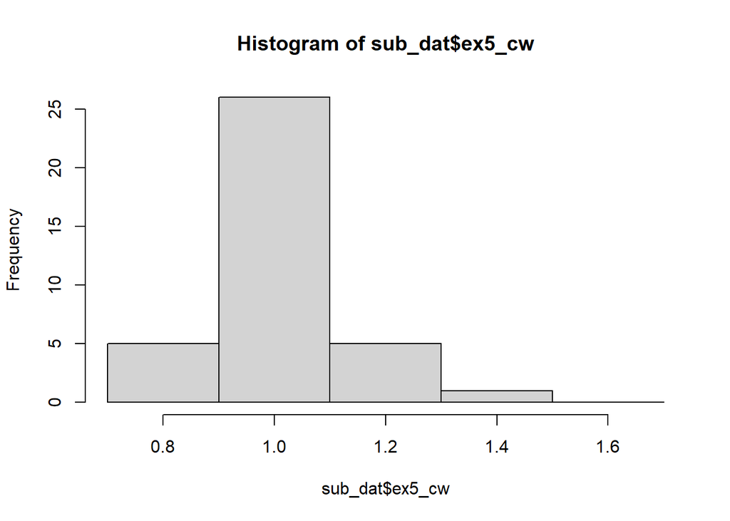

```r
hist(sub_dat$ex5_cw, seq(0.7,1.7,0.2))
```